# Exercise Solutions: EDA

University of North Carolina at Chapel Hill

## Setup

**Download Data**  
Boston AirBnB Data

```r
# Load the tidyverse package.
library(tidyverse)

# Read in the data and store it as a data frame object called "listings".
listings <- read_csv("data/Boston_listings.csv")
```

### 1. Make a scatterplot of review_scores_rating vs reviews_per_month. Add a best fit linear regression line with `geom_smooth` (check the help with `?geom_smooth`, or refer back to [week one](https://unc-libraries-data.github.io/R-Open-Labs/week1_Introduction/R_OpenLabs_1_Introduction.html))

**Answer**

Just the scatterplot:

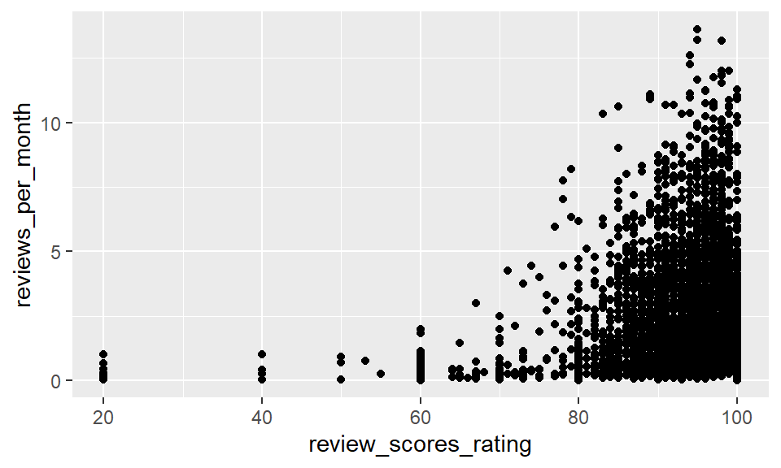

```r
ggplot(listings, aes(x=review_scores_rating, y=reviews_per_month)) +
  geom_point()
```

Scatterplot with linear regression line:

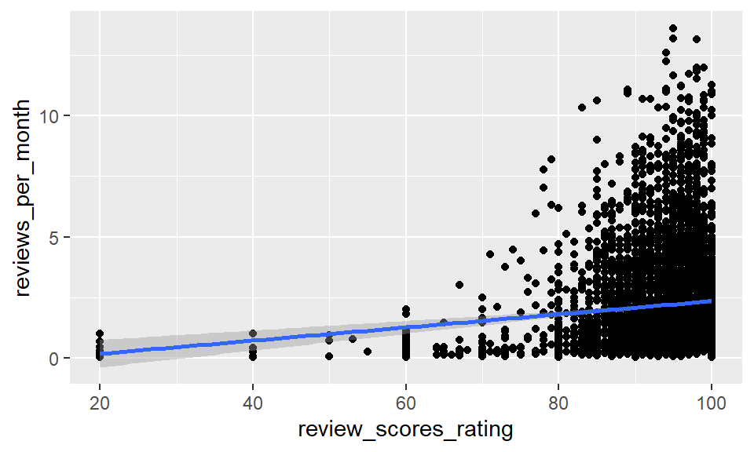

```r
ggplot(listings, aes(x=review_scores_rating, y=reviews_per_month)) +
  geom_point() +
  geom_smooth(method="lm")
```

### 2. Which neighborhoods have the highest median price? Which neighborhoods have the highest variance or largest IQR? Hint: Use `neighbourhood_cleansed` for neighborhoods.

**Answer:**  
Downtown has the highest median price.

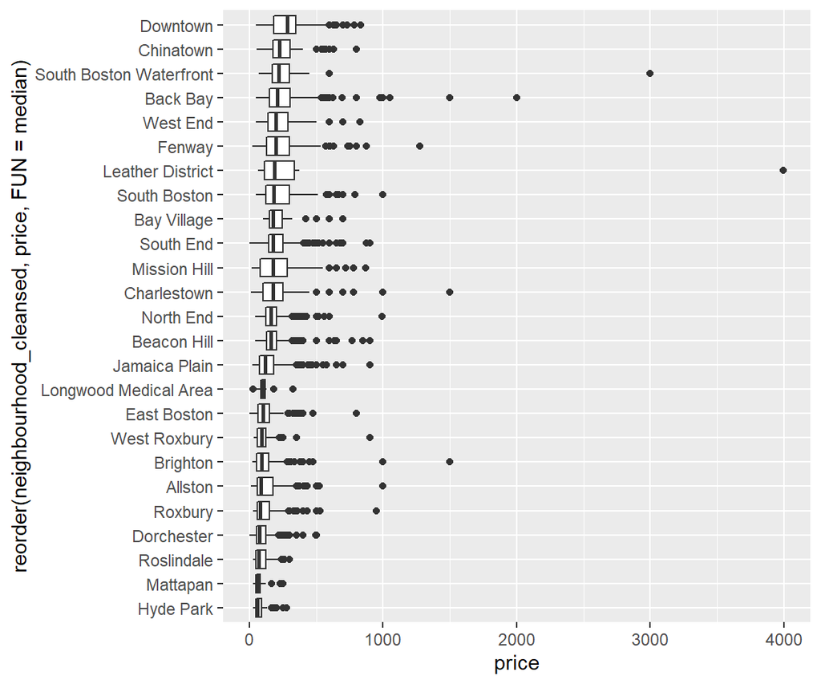

```r
ggplot(listings,aes(x=reorder(neighbourhood_cleansed, price, FUN = median),
                    y=price)) +
  geom_boxplot() + coord_flip()
```

The Leather District has the highest variance and IQR

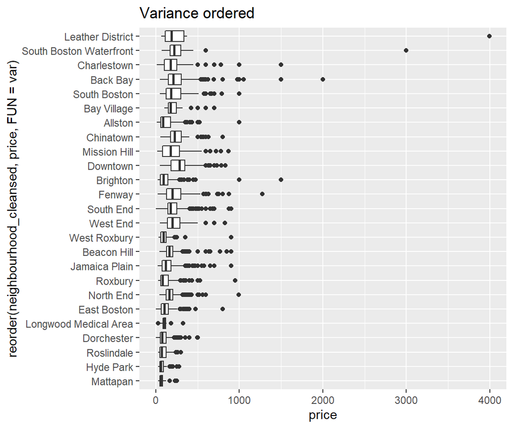

```r
#Variance
ggplot(listings,aes(x=reorder(neighbourhood_cleansed, price, FUN = var),
                    y=price)) +
  geom_boxplot() + coord_flip()+
  ggtitle("Variance ordered")
```

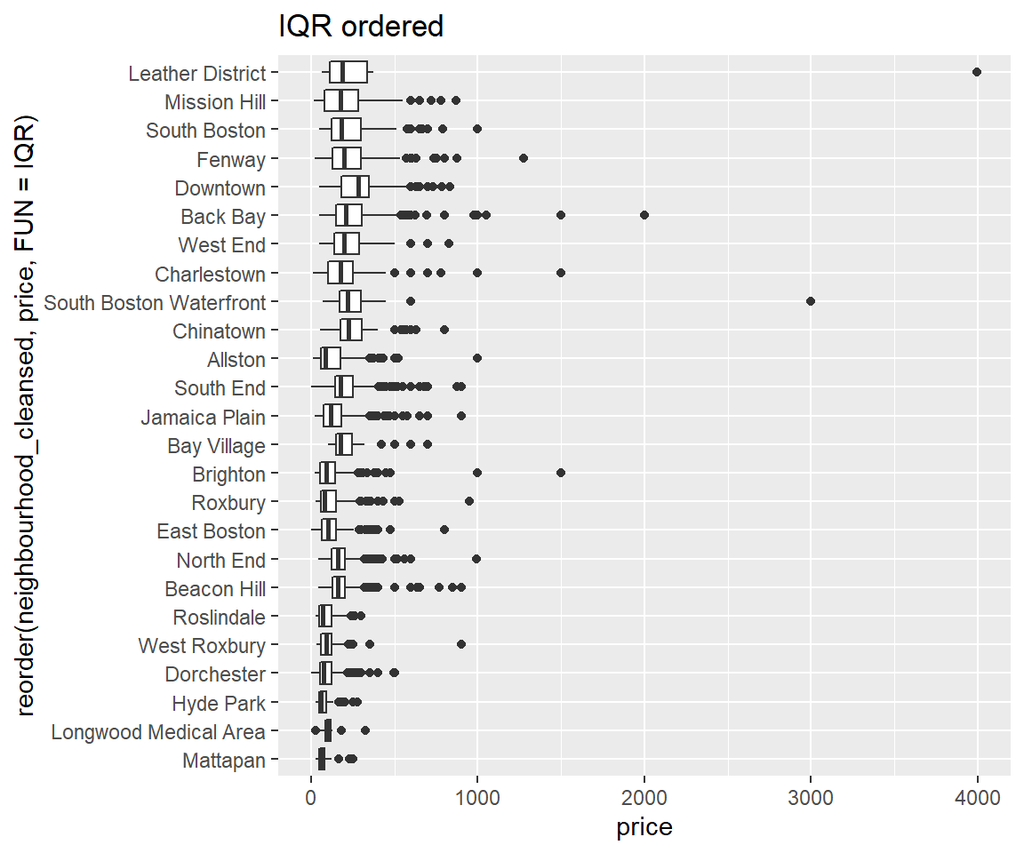

```r
#IQR
ggplot(listings,aes(x=reorder(neighbourhood_cleansed, price, FUN = IQR),
                    y=price)) +
  geom_boxplot() + coord_flip()+
  ggtitle("IQR ordered")
```

### 3. Load the built-in dataset `mpg` with `data(mpg)`. Use `?mpg` to learn more about the variables included. Come up with a hypothesis or expectation you have about the data and check it with one of the methods used above.

**Answer:**  
There are many possible solutions here! Let’s look at some basic information:

```r
data(mpg)
#?mpg
table(mpg$class)
```

```
##
##    2seater    compact    midsize    minivan     pickup subcompact        suv
##          5         47         41         11         33         35         62
```

```r
table(mpg$year)
```

```
##
## 1999 2008
##  117  117
```

Hypothesis: The proportion of compact cars increases over the two time periods. Let’s test it with a plot:

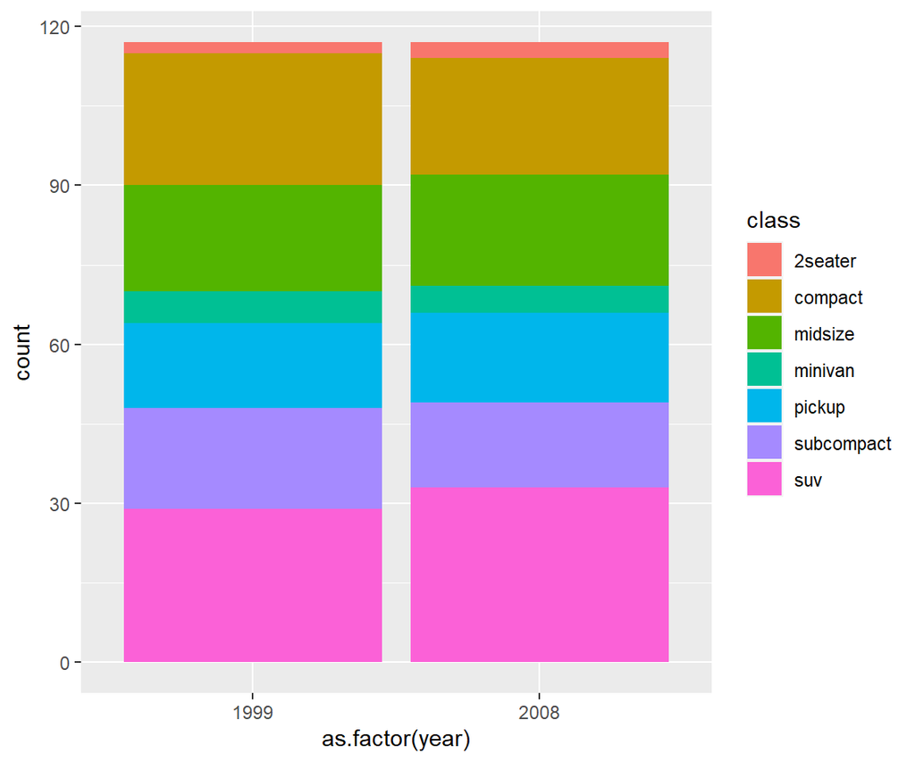

```r
ggplot(mpg,aes(x=as.factor(year),fill=class)) + geom_bar()
```

This might be a little clearer with some of our tools from week 3:

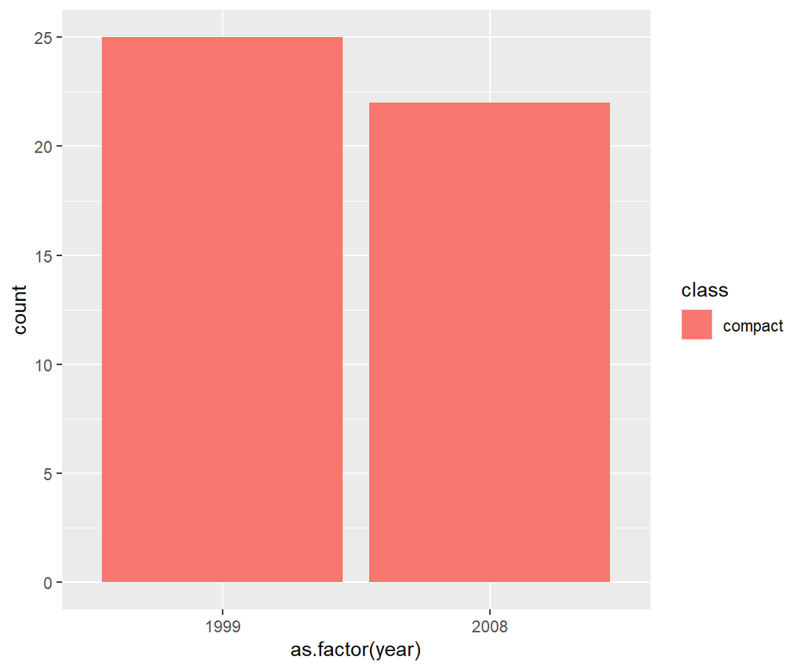

```r
mpg %>% filter(class == "compact") %>%
  ggplot(aes(x=as.factor(year),fill=class)) + geom_bar()
```

### 4. Load the built-in dataset `msleep` with `data(msleep)`. Use `?msleep` to learn more about the variables included. Come up with a hypothesis or expectation you have about the data and check it with one of the methods used above.

**Answer:**  
There are many possible solutions here! Let’s look at some basic information:

```r
data(msleep)
#?msleep
summary(msleep$brainwt)
```

```
##    Min. 1st Qu.  Median    Mean 3rd Qu.    Max.    NA's
## 0.00014 0.00290 0.01240 0.28158 0.12550 5.71200      27
```

```r
summary(msleep$sleep_rem)
```

```
##    Min. 1st Qu.  Median    Mean 3rd Qu.    Max.    NA's
##   0.100   0.900   1.500   1.875   2.400   6.600      22
```

Hypothesis: Animals with larger brains experience more REM sleep.

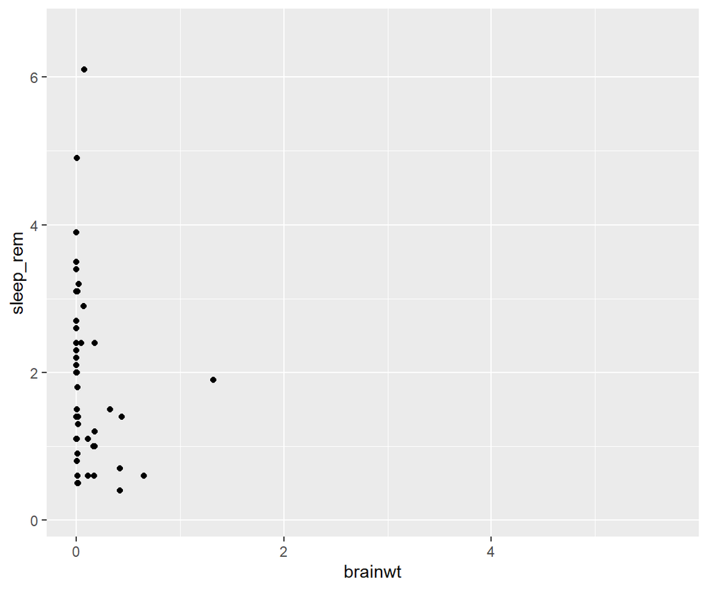

```r
ggplot(data=msleep, aes(x=brainwt, y=sleep_rem))+
  geom_point()
```

There doesn’t seem to be too much to this hypothesis! What if we normalize both variables - considering instead the ratio of brain weight to body weight and REM sleep to total sleep?

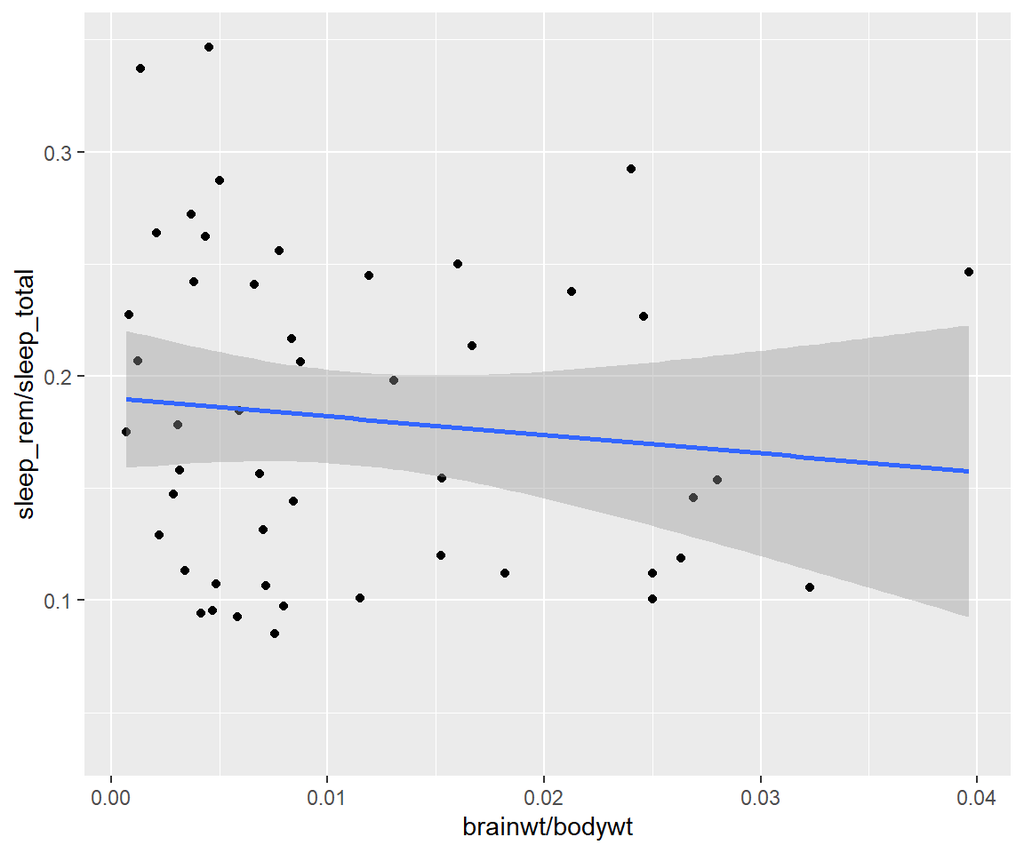

```r
ggplot(data=msleep, aes(x=brainwt/bodywt, y=sleep_rem/sleep_total))+
  geom_point()+
  geom_smooth(method="lm")
```

It looks like there may be a slight downward trend here, but we don’t have strong evidence. Sometimes EDA doesn’t lead us to strong conclusions!